# Problem Set #1 - `dplyr` basics

Data Wrangling with `dplyr`

Pham Thai Ha Cao

2023-01-25

## Directions

```r
install.packages("magrittr") # package installations are only needed the first time you use it
install.packages("dplyr")    # alternative installation of the %>%
library(dplyr)    # alternatively, this also loads %>%
```

```r
install.packages("ggplot2")
library(ggplot2)
```

During ANLY 512 we will be studying the theory and practice of *data visualization*. We will be using `R` and the packages within `R` to assemble data and construct many different types of visualizations. Before we begin studying data visualizations we need to develop some data wrangling skills. We will use these skills to wrangle our data into a form that we can use for visualizations.

The objective of this assignment is to introduce you to R Studio, Rmarkdown, the tidyverse and more specifically the `dplyr` package.

Each question is worth 5 points.

To submit this homework you will create the document in Rstudio, using the knitr package (button included in Rstudio) and then submit the document to your [Rpubs](http://rpubs.com/) account. Once uploaded you will submit the link to that document on Canvas. Please make sure that this link is hyper linked and that I can see the visualization and the code required to create it.

Question #1

```r
install.packages("nycflights13")
library(nycflights13)
cancelled_flights <- flights %>%
  group_by(month) %>%
  summarize(Number_cancelled_flights =  sum(is.na(arr_delay)),
            total = n(),
            proportion_cancelled = Number_cancelled_flights/total) %>%
  arrange(desc(proportion_cancelled))

cancelled_flights
```

```
## # A tibble: 12 × 4
##    month Number_cancelled_flights total proportion_cancelled
##    <int>                    <int> <int>                <dbl>
##  1     2                     1340 24951              0.0537
##  2     6                     1168 28243              0.0414
##  3    12                     1115 28135              0.0396
##  4     7                     1132 29425              0.0385
##  5     3                      932 28834              0.0323
##  6     4                      766 28330              0.0270
##  7     5                      668 28796              0.0232
##  8     1                      606 27004              0.0224
##  9     9                      564 27574              0.0205
## 10     8                      571 29327              0.0195
## 11    11                      297 27268              0.0109
## 12    10                      271 28889              0.00938
```

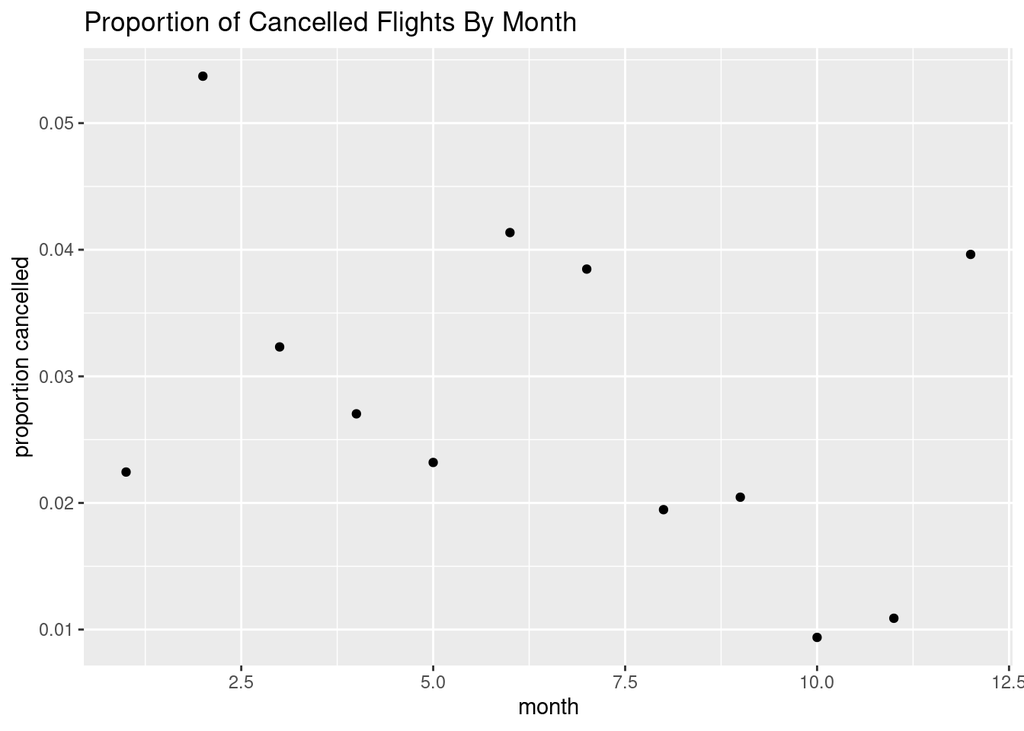

```r
cancelled_flights %>% ggplot(aes(x = month, y = proportion_cancelled)) +
  geom_point() +
  labs(title = "Proportion of Cancelled Flights By Month",
       y = "proportion cancelled")
```

Question #2

Consider the following pipeline:

```r
library(tidyverse)
mtcars %>%
  group_by(cyl) %>%
  summarize(avg_mpg = mean(mpg)) %>%
  filter(am == 1)
```

What is the problem with this pipeline?

The problem of this pipeline is the filtering step was done after the group and summarize steps. After the group and summarize steps,the dataset were reduced to cyl and avg_mpg column so the filtering could not be done. The filtering step should be done before group and summarize.

Question #3

Define two new variables in the `Teams` data frame in the `pkg Lahman()` package.

1. batting average (BA). Batting average is the ratio of hits (H) to at-bats (AB)
2. slugging percentage (SLG). Slugging percentage is total bases divided by at-bats (AB). To compute total bases, you get 1 for a single, 2 for a double, 3 for a triple, and 4 for a home run.

```r
#batting average (BA). Batting average is the ratio of hits (H) to at-bats (AB)
install.packages("Lahman")
library(Lahman)
Teams = Teams %>%
    mutate(BA = H / AB)
summary(Teams$BA)
```

```
##    Min. 1st Qu.  Median    Mean 3rd Qu.    Max.
##  0.1564  0.2494  0.2600  0.2607  0.2708  0.3498
```

```r
#slugging percentage (SLG). Slugging percentage is total bases divided by at-bats (AB). To compute total bases, you get 1 for a single, 2 for a double, 3 for a triple, and 4 for a home run.

Teams = Teams %>%
    mutate(SLG = (H + 2 * X2B + 3 * X3B + 4 * HR) / AB)
summary(Teams$SLG)
```

```
##    Min. 1st Qu.  Median    Mean 3rd Qu.    Max.
##  0.1659  0.4192  0.4596  0.4561  0.4950  0.6093
```

Question #4

Using the `Teams` data frame in the `pkg Lahman()` package. display the top-5 teams ranked in terms of slugging percentage (SLG) in Major League Baseball history. Repeat this using teams since 1969. Slugging percentage is total bases divided by at-bats.To compute total bases, you get 1 for a single, 2 for a double, 3 for a triple, and 4 for a home run.

```r
#the top-5 teams ranked in terms of slugging percentage (SLG) in Major League Baseball history
library(Lahman)
Teams %>%
    select(name, yearID, SLG) %>%
    arrange(desc(SLG)) %>%
    head(5)
```

```
##               name yearID       SLG
## 1   Houston Astros   2019 0.6092998
## 2  Minnesota Twins   2019 0.6071179
## 3   Boston Red Sox   2003 0.6033975
## 4 New York Yankees   2019 0.5996776
## 5   Atlanta Braves   2020 0.5964320
```

```r
# Top 5 teams in terms of SLG since 1969
Teams %>%
    select(name, yearID, SLG) %>%
    filter(yearID >= 1969) %>%
    arrange(desc(SLG)) %>%
    head(5)
```

```
##               name yearID       SLG
## 1   Houston Astros   2019 0.6092998
## 2  Minnesota Twins   2019 0.6071179
## 3   Boston Red Sox   2003 0.6033975
## 4 New York Yankees   2019 0.5996776
## 5   Atlanta Braves   2020 0.5964320
```

Question #5

Use the `Batting`, `Pitching`, and `People` tables in the `pkg Lahman()` package to answer the following questions.

a.Name every player in baseball history who has accumulated at least 300 home runs (HR) and at least 300 stolen bases (SB). You can find the first and last name of the player in the Master data frame. Join this to your result along with the total home runs and total bases stolen for each of these elite players.

1. Similarly, name every pitcher in baseball history who has accumulated at least 300 wins (W) and at least 3,000 strikeouts (SO).
2. Identify the name and year of every player who has hit at least 50 home runs in a single season. Which player had the lowest batting average in that season?

```r
#Name every player in baseball history who has accumulated at least 300 home runs (HR) and at least 300 stolen bases (SB).
library(Lahman)
Batting %>%
    group_by(playerID) %>%
    summarize(total_home_runs = sum(HR), total_stolen_bases = sum (SB)) %>%
    filter(total_home_runs >= 300 & total_stolen_bases >= 300) %>%
    inner_join(People, by = c("playerID" = "playerID")) %>%
    select(nameFirst, nameLast, total_home_runs, total_stolen_bases)
```

```
## # A tibble: 8 × 4
##   nameFirst nameLast  total_home_runs total_stolen_bases
##   <chr>     <chr>               <int>              <int>
## 1 Carlos    Beltran               435                312
## 2 Barry     Bonds                 762                514
## 3 Bobby     Bonds                 332                461
## 4 Andre     Dawson                438                314
## 5 Steve     Finley                304                320
## 6 Willie    Mays                  660                338
## 7 Alex      Rodriguez             696                329
## 8 Reggie    Sanders               305                304
```

```r
#name every pitcher in baseball history who has accumulated at least 300 wins (W) and at least 3,000 strikeouts (SO).
Pitching %>%
    group_by(playerID) %>%
    summarize(total_wins = sum(W), total_strikeouts = sum(SO)) %>%
    filter(total_wins >= 300 & total_strikeouts >= 3000) %>%
    inner_join(People, by =  c("playerID" = "playerID")) %>%
    select(nameFirst, nameLast, nameGiven, total_wins, total_strikeouts)
```

```
## # A tibble: 10 × 5
##    nameFirst nameLast nameGiven       total_wins total_strikeouts
##    <chr>     <chr>    <chr>                <int>            <int>
##  1 Steve     Carlton  Steven Norman          329             4136
##  2 Roger     Clemens  William Roger          354             4672
##  3 Randy     Johnson  Randall David          303             4875
##  4 Walter    Johnson  Walter Perry           417             3509
##  5 Greg      Maddux   Gregory Alan           355             3371
##  6 Phil      Niekro   Philip Henry           318             3342
##  7 Gaylord   Perry    Gaylord Jackson        314             3534
##  8 Nolan     Ryan     Lynn Nolan             324             5714
##  9 Tom       Seaver   George Thomas          311             3640
## 10 Don       Sutton   Donald Howard          324             3574
```

```r
#Identify the name and year of every player who has hit at least 50 home runs in a single season. Which player had the lowest batting average in that season?
homerun_players = Batting %>%
    group_by(playerID, yearID) %>%
    summarize(total_home_runs = sum(HR), batting_avg = sum(H) / sum(AB)) %>%
    filter(total_home_runs >= 50) %>%
    inner_join(People, by = c("playerID" = "playerID")) %>%
    select(yearID, nameFirst, nameLast, total_home_runs, batting_avg) %>%
    arrange(batting_avg)
homerun_players
```

```
## # A tibble: 46 × 6
## # Groups:   playerID [30]
##    playerID  yearID nameFirst nameLast total_home_runs batting_avg
##    <chr>      <int> <chr>     <chr>              <int>       <dbl>
##  1 alonspe01   2019 Pete      Alonso                53       0.260
##  2 bautijo02   2010 Jose      Bautista              54       0.260
##  3 jonesan01   2005 Andruw    Jones                 51       0.263
##  4 marisro01   1961 Roger     Maris                 61       0.269
##  5 vaughgr01   1998 Greg      Vaughn                50       0.272
##  6 mcgwima01   1997 Mark      McGwire               58       0.274
##  7 fieldce01   1990 Cecil     Fielder               51       0.277
##  8 mcgwima01   1999 Mark      McGwire               65       0.278
##  9 stantmi03   2017 Giancarlo Stanton               59       0.281
## 10 judgeaa01   2017 Aaron     Judge                 52       0.284
## # … with 36 more rows
```